# act_report

## Report: Insights and Visualization Report

### Introduction

After the Wrangling Process, the cleaned datasets were combined and stored as one dataset (twitter_master_archive.csv) which was then, analyzed and visualized. This report highlights a summary of the activities that were carried out in this data wrangling project and the insights that were obtained.

The processes involved were:

[x] Data Gathering

[x] Data Assessment

[x] Data Cleaning

[x] Data Storing

[x] Data Analysis and Visualization

[x] Data Reporting

Three datasets (a twitter_archive_enhanced.csv file provided by Udacity, an image_prediction.tsv file also provided by Udacity and a tweet_json.txt file which was accessed from the renowned Twitter company).

The twitter_archive_enhanced.csv file was downloaded manually through a link in the course content, the image_prediction.tsv file was downloaded programmatically from Udacity servers right from my Jupyter Notebook (using Anaconda software and connecting to the internet) while the tweet_json.txt file was created after obtaining developer access from Twitter and querying the WeRateDogs account via Twitter's API for the required tweets.

The twitter_archive_enhanced.csv file contained basic information about 2356 tweets, the image_prediction.tsv file contained 2075 predictions while the tweet_json.txt file contained the tweet IDs, rewteet count and favorite count of 2325 valid or accessible tweets.

While assessing the data, several quality and tidiness issues were observed but 8 quality issues (excluding repeated issues) and 3 tidiness issues were given attention. Diverse methods in the pandas library were used to carrying out assessment and cleaning and the three datasets were eventually merged into a datatset with 2297 rows and 22 columns. The merged dataset was then stored as a master_twitter_archive.csv file.

The 22 columns of the master dataset had the following titles:

> tweet_id, timestamp, source, text, expanded_urls, rating_numerator, rating_denominator, name, dog_type, jpg_url, img_num, p1, p1_conf, p1_dog, p2, p2_conf, p2_dog, p3, p3_conf, p3_dog, retweet_count and favorite_count.

### Insights

The insights obtained or gathered from the resultant master file are:

1. 67% of the types of dogs **indicated in the tweets** are puppers, 23% are doggos, 8.7% are puppos 1% are floofers.
1. The highest number of retweets is 70669, the mean number of retweets is 2529 and the lowest number of retweets is 11.
1. The highest favourite count is 144802, the mean is 7197 and the minimum is 0.

### Visualizations

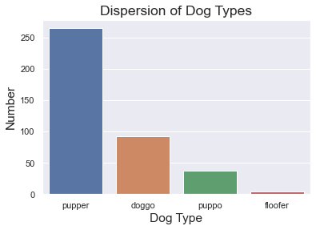

Pupper is the most popular dog type while Floofer is the least popular, based on the analysis of non-missing values of dog type.

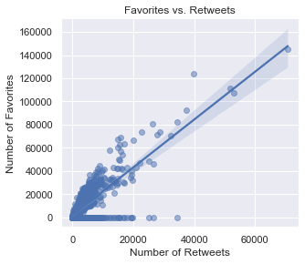

The number of retweets and the number of favorites are strongly positively correlated. However, the behavior of one of the two tweet attributes may not be the cause of the behavior of the other.

**"Thank you for reading!"**